# Reporte técnico de priorización territorial: SAIDI y SAIFI por cuadrante

Grupo 4 — Maestría en Ciencia de Datos, PUJ Cali

27 de octubre de 2026

# Propósito y alcance

Este reporte traduce los resultados de la tesis en un **ordenamiento de cuadrantes** que el operador puede usar para orientar la inversión, el mantenimiento preventivo, la poda y la programación de cuadrillas. Responde a dos preguntas:

1. **¿Dónde se concentra estructuralmente la afectación?** Nivel de SAIDI y SAIFI de cada cuadrante en 2024–2025 y su participación en la afectación total.
2. **¿Dónde es más probable una falla la semana próxima?** Probabilidad semanal de falla estimada con el clasificador validado en la Etapa 5 (AUC = 0,84).

**Alcance.** SAIDI y SAIFI por cuadrante son *indicadores operativos de afectación* referidos a los usuarios totales de la empresa (UT mensual). Sirven para **ordenar** zonas; no son el indicador regulatorio desagregado ni se suman al valor oficial (Apéndice de robustez de la tesis: correlación de rangos de 0,87 con la versión evento a evento). La magnitud semanal no es pronosticable con la información disponible, por lo que este reporte no pronostica horas de interrupción por semana.

# 1. Concentración estructural de la afectación

La afectación está muy concentrada: **6 de los 344 cuadrantes (1.7 %) acumulan la mitad del SAIDI operativo de 2024–2025** y 30 cuadrantes acumulan el 80 %. Para SAIFI, la mitad se concentra en 9 cuadrantes y el 80 % en 41.

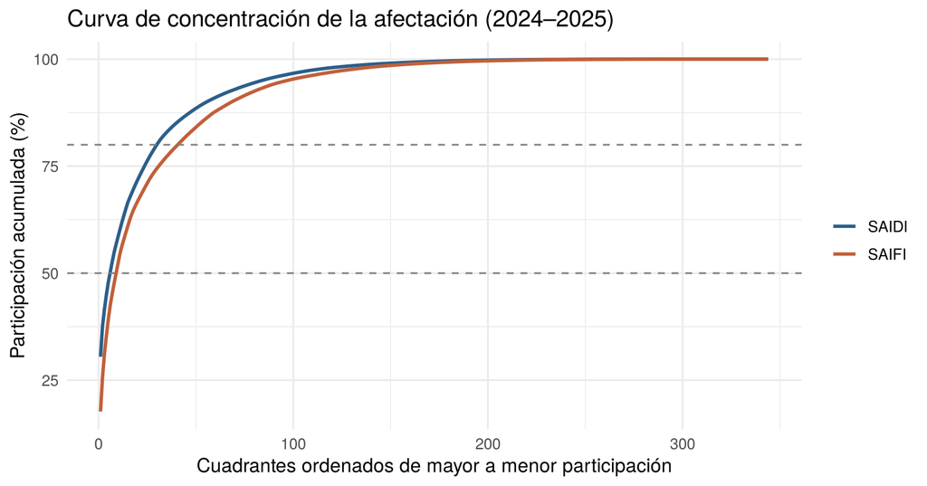

# 2. Probabilidad semanal de falla

Se reproduce el componente de ocurrencia de la Etapa 5: un bosque aleatorio de clasificación entrenado con las semanas hasta el 08/09/2025 y predictoras disponibles antes de la semana pronosticada (clima, NDVI y sismicidad de la semana anterior, falla de la semana anterior, infraestructura y composición de usuarios). Se reporta la probabilidad media pronosticada en las 16 semanas de prueba.

En el conjunto de prueba el clasificador alcanza un **AUC de 0.836**. La calibración por deciles muestra que la probabilidad pronosticada ordena bien el riesgo: en el decil más alto la tasa observada de falla es de 90.7%, frente a 2.0% en el más bajo.

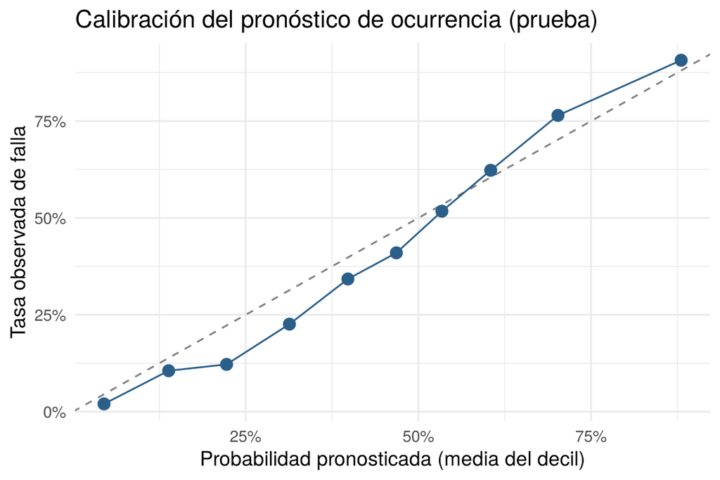

# 3. Ranking de priorización

Cada cuadrante recibe una **clase de prioridad** según su participación en la afectación:

- **A — crítica:** cuadrantes que, ordenados de mayor a menor, acumulan el primer 50 % del SAIDI o del SAIFI operativo.
- **B — alta:** los que completan hasta el 80 %.
- **C — seguimiento:** el resto.

La probabilidad semanal de falla se añade como segunda dimensión para la operación. Las **orientaciones de gestión** son reglas indicativas derivadas de las variables que la tesis identificó como relevantes; no son efectos causales estimados y deben validarse con el conocimiento técnico del operador.

Resultado: **10 cuadrantes en prioridad A**, 37 en B y 297 en C. El listado completo se exporta en `priorizacion_cuadrantes.csv`.

Cuadrantes de prioridad A (hasta 30, ordenados por participación en SAIDI)

| Cuadrante | Municipio | Rango SAIDI | % SAIDI | Rango SAIFI | % SAIFI | P(falla) semanal | Orientación |
| --- | --- | --- | --- | --- | --- | --- | --- |
| 117 | Cúcuta | 1 | 30.48 | 1 | 17.68 | 98% | Seccionamiento y protecciones (reconectadores) para reducir usuarios por falla; Reducir tiempos de acceso y restablecimiento (red extensa); Programación preventiva de cuadrillas (probabilidad semanal … |
| 107 | Los Patios | 2 | 7.03 | 2 | 7.89 | 96% | Seccionamiento y protecciones (reconectadores) para reducir usuarios por falla; Reducir tiempos de acceso y restablecimiento (red extensa); Programación preventiva de cuadrillas (probabilidad semanal … |
| 296 | Tibú | 3 | 4.02 | 8 | 2.47 | 68% | Reducir tiempos de acceso y restablecimiento (red extensa); Programación preventiva de cuadrillas (probabilidad semanal alta) |
| 116 | Cúcuta | 4 | 3.40 | 6 | 3.31 | 93% | Seccionamiento y protecciones (reconectadores) para reducir usuarios por falla; Reducir tiempos de acceso y restablecimiento (red extensa); Programación preventiva de cuadrillas (probabilidad semanal … |
| 126 | Cúcuta | 5 | 2.97 | 4 | 4.15 | 98% | Seccionamiento y protecciones (reconectadores) para reducir usuarios por falla; Reducir tiempos de acceso y restablecimiento (red extensa); Programación preventiva de cuadrillas (probabilidad semanal … |
| 198 | Cúcuta | 6 | 2.38 | 10 | 2.30 | 69% | Seccionamiento y protecciones (reconectadores) para reducir usuarios por falla; Reducir tiempos de acceso y restablecimiento (red extensa); Programación preventiva de cuadrillas (probabilidad semanal … |
| 310 | Tibú | 9 | 1.85 | 3 | 5.58 | 78% | Seccionamiento y protecciones (reconectadores) para reducir usuarios por falla; Programación preventiva de cuadrillas (probabilidad semanal alta) |
| 203 | Aguachica | 11 | 1.71 | 5 | 3.94 | 89% | Seccionamiento y protecciones (reconectadores) para reducir usuarios por falla; Programación preventiva de cuadrillas (probabilidad semanal alta) |
| 38 | Pamplona | 18 | 1.07 | 9 | 2.35 | 86% | Seccionamiento y protecciones (reconectadores) para reducir usuarios por falla; Programación preventiva de cuadrillas (probabilidad semanal alta) |
| 190 | Ocaña | 42 | 0.37 | 7 | 2.64 | 60% | Seccionamiento y protecciones (reconectadores) para reducir usuarios por falla; Programación preventiva de cuadrillas (probabilidad semanal alta) |

# 4. Mapas

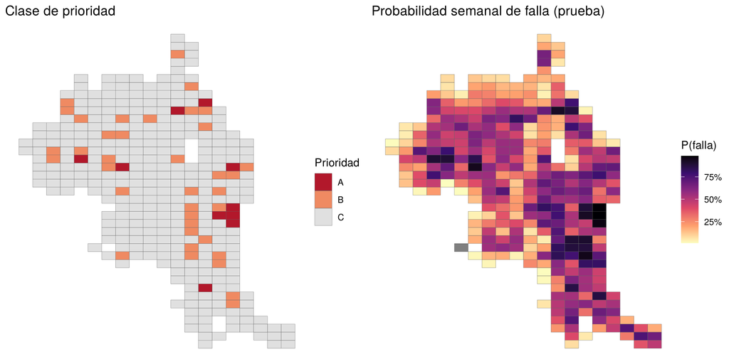

# 5. Uso recomendado y actualización

- **Planeación anual (inversión, reposición y poda):** priorizar los cuadrantes de clase A; dentro de ellos, la orientación indica la palanca principal sugerida por sus características.
- **Programación semanal:** recalcular la probabilidad de falla cada semana con los datos de la semana anterior y asignar cuadrillas preventivas a los cuadrantes del cuartil superior.
- **Seguimiento:** reestimar el ranking cada trimestre con el panel actualizado y comparar la participación de los cuadrantes A antes y después de las intervenciones.
- **Limitaciones:** la clase de prioridad se basa en la afectación observada en 2024–2025; los cuadrantes 68, 140, 333 y 344 no tienen usuarios en la fuente comercial, y la “edad” de los activos mide la distancia a la última intervención, no la antigüedad.

*Reproducibilidad:* este informe se genera con `Etapa6_01_reporte_priorizacion.Rmd` a partir de `data_final_modelo_cuadrantes_reales_sismos_corr.rds` e `infraestructura_cuadrantes_reales.gpkg`.